# Simulation using the exponential distribution

Hashdevrunner

# Executive Summary

One of the most important part of learning Statistical Inference subject is to understand the intricacies of distribution functions. It is interesting to verify the effects on expectancy as study begins to gather more data. Using the tools available, the exponential distribution can be simulated in R using function `rexp(n, lambda)`, where $lambda(\lambda)$ is the rate of the parameter and `n` $n$ is number of samples.

For exponential distribution PDF, the mean and standard deviation can be derived as: $\begin{aligned} \mu = \frac{1}{\lambda} = \sigma \end{aligned}$

## Simulation of values

To begin with the simulation, we need to create a 1000 simulations for 40 random values. It could be achieved with the code:

```r
library(ggplot2)
library(gridExtra)
set.seed(0)
noSim <- 1e3
lambda <- 0.2
#create a simulation of exponential distribution in a 1000x40 matrix
sim <- matrix(rexp(noSim*40, rate=lambda), noSim, 40)
```

From these simulated values, obtain means for each row and display the histogram to verify if the distribution will seem to be normal.

```r
#generate data set for means of the rows
data_est <- data.frame(r = rowMeans(sim),
                       z = as.factor("Actual"))
```

Compare the estimated density of the distribution vs theoretical normal distribution.

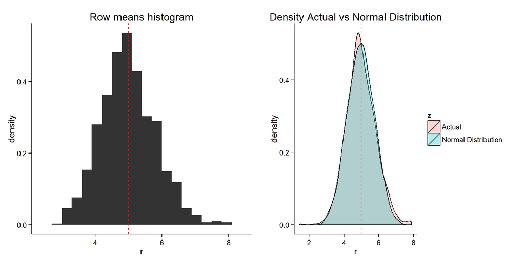

```r
#show to histogram
ghist <- ggplot(data_est,aes(x=r)) +
  geom_histogram(binwidth = .3, aes(y=..density..)) +
  theme_classic() +
  ggtitle(label = "Row means histogram") +
  geom_vline(xintercept = 5, color = "red", linetype = "dashed")

#data set for theoretical normal distribution
data_th <- data.frame(
  r = rnorm(noSim,mean=1/lambda,sd=1/lambda/sqrt(40)),
  z = as.factor("Normal Distribution")
  )

#create one big data set
data_src <- rbind(data_est,data_th)

#Plot side by side
gplot_density <- ggplot(data_src, aes(x=r,fill=z)) +
  geom_density(alpha=.3) +
  theme_classic() +
  ggtitle(label = "Density Actual vs Normal Distribution") +
  geom_vline(xintercept = 5, color = "red", linetype = "dashed")
grid.arrange(ghist, gplot_density, nrow = 1)
```

## CLT

From the graph, we expect from the CLT, that theoretical vs actual probability distribution are very close.

```r
library(pander)
tab_df <- data.frame(Mean = c(mean(rowMeans(sim)),1/lambda),
                     Variance = c(mean(apply(sim,1,var)),1/lambda^2))
rownames(tab_df) <- c("Simulated","Theoretical")
pander(tab_df, round=2)
```

|  | Mean | Variance |
| --- | --- | --- |
| **Simulated** | 4.99 | 25.24 |
| **Theoretical** | 5 | 25 |

# Evaluation of coverage of CI

Finally, let’s evaluate the coverage of the confidence interval for $1/\lambda = \bar{X} \pm 1.96 \frac{S}{\sqrt{n}}$

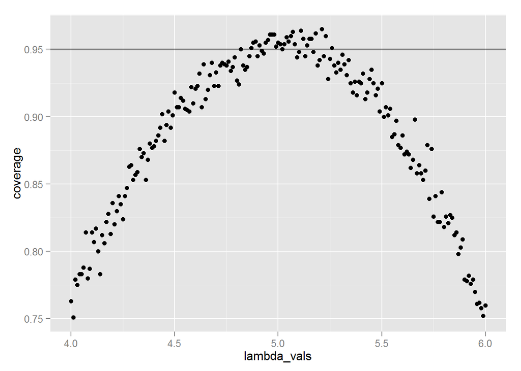

```r
set.seed(0)
lambda_vals <- seq(4, 6, by=0.01)
coverage <- sapply(lambda_vals, function(lamb) {
    mu_hats <- rowMeans(matrix(rexp(40*noSim, rate=0.2),
                               noSim, 40))
    ll <- mu_hats - qnorm(0.975) * sqrt(1/lambda**2/40)
    ul <- mu_hats + qnorm(0.975) * sqrt(1/lambda**2/40)
    mean(ll < lamb & ul > lamb)
})

qplot(lambda_vals, coverage) + geom_hline(yintercept=0.95)
```

```r
mean(lambda_vals)
```

```
## [1] 5
```

#### Reproducible code: [link](https://github.com/HashDevRunner/statsinferenceproj)